# Iranian Churn: A Comparative Analysis of Regularization and Support Vector Models for Customer Value and Churn Prediction

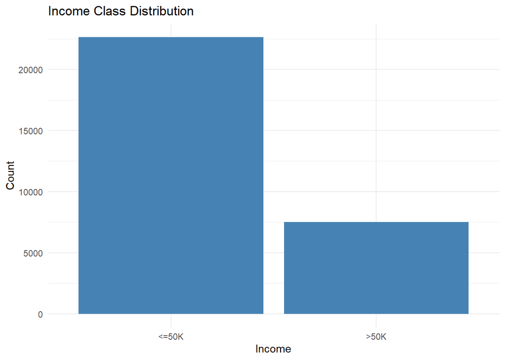

```r
ggplot(adult, aes(x = income)) +
  geom_bar(fill = "steelblue") +
  theme_minimal() +
  labs(title = "Income Class Distribution", x = "Income", y = "Count")
```

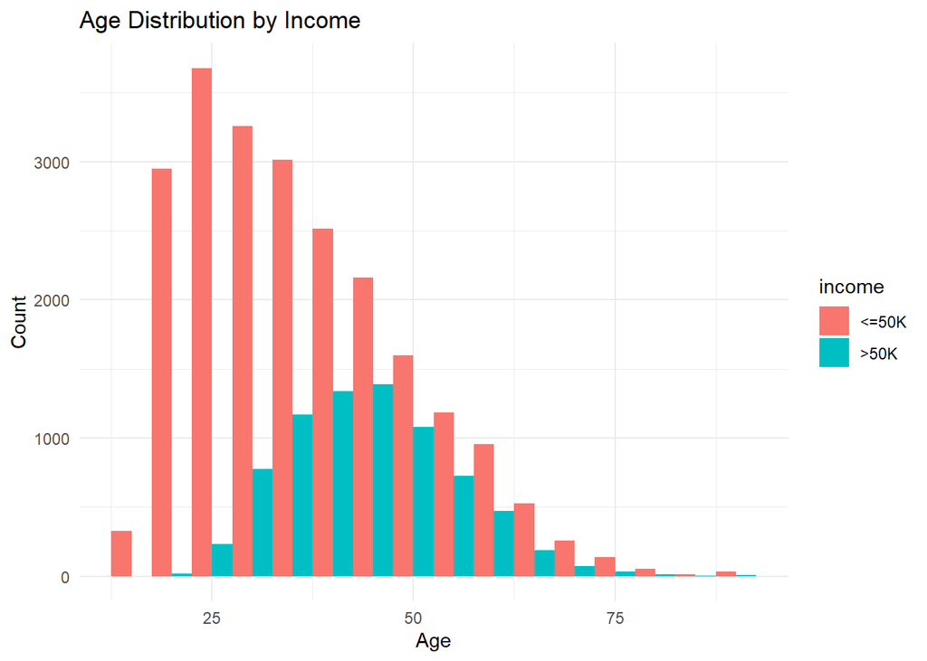

```r
ggplot(adult, aes(x = age, fill = income)) +
  geom_histogram(binwidth = 5, position = "dodge") +
  theme_minimal() +
  labs(title = "Age Distribution by Income", x = "Age", y = "Count")
```

Now a corplot will be used to determine if any of the features are strong predictors with income. We apply correlation and importance plots to identify significant predictors.

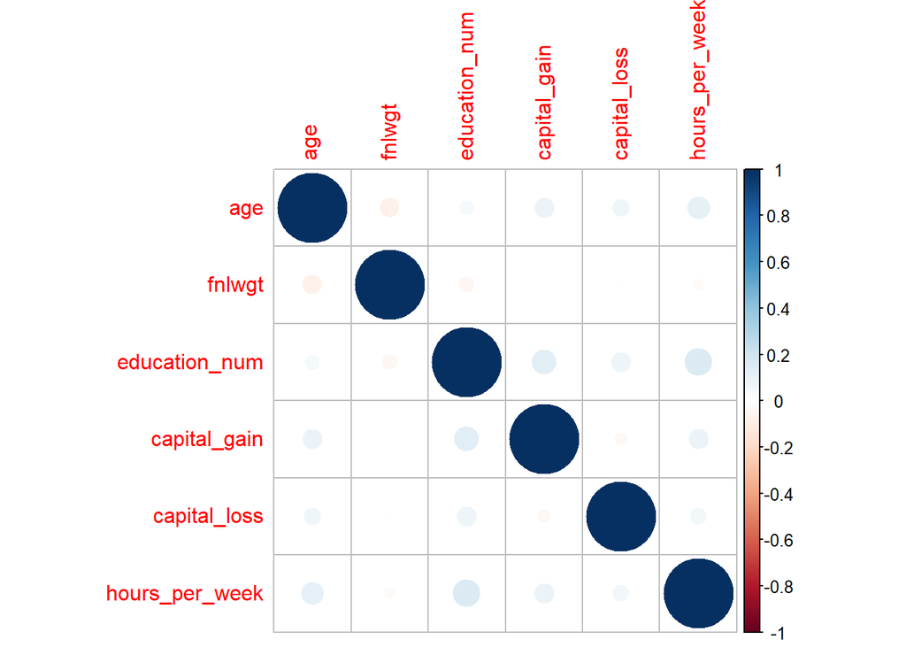

```r
corr_data <- adult %>% select_if(is.numeric)
corrplot(cor(corr_data), method = "circle")
```

## 3 Feature Engineering

Before modeling, we need derive and clean variables to ensure optimal model performance. This can be seen below

```r
adult$capital_diff <- adult$capital_gain - adult$capital_loss
adult <- adult %>% select(-capital_gain, -capital_loss)
adult <- adult %>% mutate_if(is.character, as.factor)
```

Now we will prepare the data by setting categorical variables as factors and scaling numeric variables.This will ensure that all features are on a comparable scale, which can improve our model performance.

The following features will be converted to factors below: workclass, education, marital_status, occupation, relationship, race, sex, native_country

The continuous variables: age, fnlwgt, education_num, capital_gain, capital_loss, and hours_per_week wil be scaled as well

```r
# Convert categorical variables to factors
train$workclass <- factor(train$workclass)
train$education <- factor(train$education)
train$marital_status <- factor(train$marital_status)
train$occupation <- factor(train$occupation)
train$relationship <- factor(train$relationship)
train$race <- factor(train$race)
train$sex <- factor(train$sex)
train$native_country <- factor(train$native_country)

test$workclass <- factor(test$workclass)
test$education <- factor(test$education)
test$marital_status <- factor(test$marital_status)
test$occupation <- factor(test$occupation)
test$relationship <- factor(test$relationship)
test$race <- factor(test$race)
test$sex <- factor(test$sex)
test$native_country <- factor(test$native_country)

# Scale numeric columns
num_vars <- c("age", "fnlwgt", "education_num", "capital_gain", "capital_loss", "hours_per_week")
train[num_vars] <- scale(train[num_vars])
```

### 3.1 Feature Selection

Feature selection helps to improve model accuracy and interpretability by removing redundant or irrelevant features.We will use a method to select the most important features: Random Forest variable importance. This will help us identify which features contribute the most to the target variable and allow us to build a more efficient model.

### 3.2 Random Forest Variable Importance

Random Forest provides an importance score for each feature, which helps to identify which features are the most useful for predicting the target variable. We will train a Random Forest model and use it to rank feature importance.

```r
# Train random forest model for feature importance
rf_model <- randomForest(income ~ ., data = train, ntree = 100, importance = TRUE)

# Get variable importance
importance(rf_model)
```

```
                    <=50K       >50K MeanDecreaseAccuracy MeanDecreaseGini
age             2.5578130 37.8268493           37.4555429         889.1015
workclass      15.5394656  2.1216774           14.5398004         281.8247
fnlwgt          0.9572426 -1.9052364           -0.5439667         811.2838
education      26.9940306  3.8447201           26.8493634         572.9593
education_num  14.9523698  6.5891075           15.7764347         473.0940
marital_status 19.9305945 11.1178879           18.8968765         803.9625
occupation     17.6502602 29.6531312           38.3170890         702.2156
relationship   12.1035701 16.9341889           16.4520003         877.4122
race            5.6230960  4.1798578            6.9532960         101.8953
sex            13.7916624 -0.3795811           15.5702315         101.2252
capital_gain   57.5400382 71.6521306           73.1321606         916.0656
capital_loss   24.2291554 35.6248597           39.4817181         261.6928
hours_per_week  0.2722752 23.5470978           19.3373621         508.1816
native_country  9.1886000 -1.4055526            6.8723206         189.9919
```

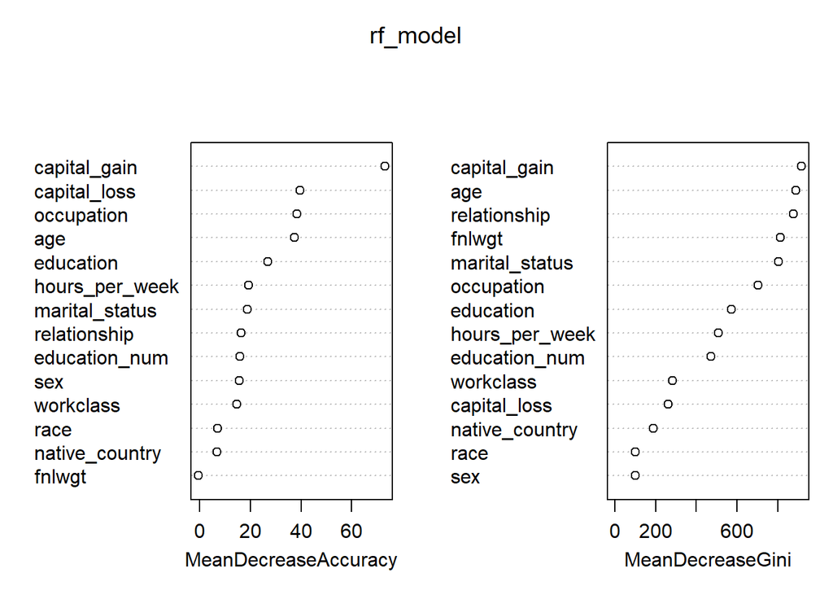

```r
# Plot variable importance
varImpPlot(rf_model)
```

## 4 CART Classification

We implement and evaluate a classification tree.

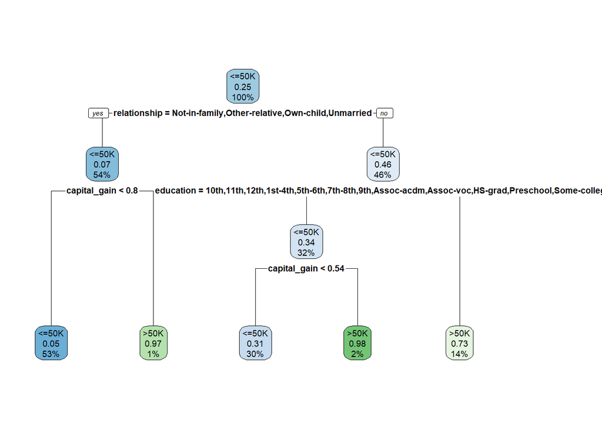

```r
cart_model <- rpart(income ~ ., data = train, method = "class", cp = 0.01)
rpart.plot(cart_model)
```

```r
printcp(cart_model)
```

```
Classification tree:
rpart(formula = income ~ ., data = train, method = "class", cp = 0.01)

Variables actually used in tree construction:
[1] capital_gain education    relationship

Root node error: 5986/24129 = 0.24808

n= 24129

        CP nsplit rel error  xerror      xstd
1 0.127965      0   1.00000 1.00000 0.0112077
2 0.066823      2   0.74407 0.75359 0.0101171
3 0.036752      3   0.67725 0.69245 0.0097881
4 0.010000      4   0.64049 0.65185 0.0095544
```

```r
# Prune based on optimal cp
opt_cp <- cart_model$cptable[which.min(cart_model$cptable[, "xerror"]), "CP"]
cart_pruned <- prune(cart_model, cp = opt_cp)

pred_cart <- predict(cart_pruned, newdata = test, type = "class")
confusionMatrix(pred_cart, test$income)
```

```
Confusion Matrix and Statistics

          Reference
Prediction <=50K >50K
     <=50K  4120  706
     >50K    391  816

               Accuracy : 0.8182
                 95% CI : (0.8082, 0.8278)
    No Information Rate : 0.7477
    P-Value [Acc > NIR] : < 2.2e-16

                  Kappa : 0.4825

 Mcnemar's Test P-Value : < 2.2e-16

            Sensitivity : 0.9133
            Specificity : 0.5361
         Pos Pred Value : 0.8537
         Neg Pred Value : 0.6761
             Prevalence : 0.7477
         Detection Rate : 0.6829
   Detection Prevalence : 0.7999
      Balanced Accuracy : 0.7247

       'Positive' Class : <=50K
```

The CART classification model demonstrates strong overall performance, achieving an accuracy of 81.8% with a 95% confidence interval ranging from 80.8% to 82.8%. It significantly outperforms the No Information Rate (74.8%), indicating that it provides meaningful predictions beyond simply guessing the most frequent class. The model shows high sensitivity (91.3%) for predicting individuals earning ≤50K, but lower specificity (53.6%) for identifying those earning >50K, suggesting it performs better with the majority class. Overall, the CART model is effective, particularly for the lower income group, though further refinement or alternative modeling approaches may improve classification of higher income individuals.

## 5 Logistic Regression

Here, we will train a logistic regression model using the training data, evaluate its performance, and compare it against more complex models like CART and Random Forest.

```r
log_model <- glm(income ~ ., data = train, family = "binomial")
pred_log <- predict(log_model, test, type = "response")
log_class <- ifelse(pred_log > 0.5, ">50K", "<=50K")
confusionMatrix(factor(log_class, levels = levels(test$income)), test$income)
```

```
Confusion Matrix and Statistics

          Reference
Prediction <=50K >50K
     <=50K     0    0
     >50K   4511 1522

               Accuracy : 0.2523
                 95% CI : (0.2414, 0.2634)
    No Information Rate : 0.7477
    P-Value [Acc > NIR] : 1

                  Kappa : 0

 Mcnemar's Test P-Value : <2e-16

            Sensitivity : 0.0000
            Specificity : 1.0000
         Pos Pred Value :    NaN
         Neg Pred Value : 0.2523
             Prevalence : 0.7477
         Detection Rate : 0.0000
   Detection Prevalence : 0.0000
      Balanced Accuracy : 0.5000

       'Positive' Class : <=50K
```

The logistic regression model performed poorly, achieving an overall accuracy of only 25.2%, which is significantly lower than the No Information Rate of 74.8%. This suggests the model failed to learn any meaningful patterns from the data. It predicted all instances as the >50K class, completely missing the majority class (<=50K), resulting in a sensitivity of 0.0% and a specificity of 100%.

Compared to more complex models like CART and Random Forest, logistic regression underperformed drastically, highlighting itS limitations in capturing nonlinear relationships or interactions in the data.

## 6 Bagging

```r
set.seed(123)
bag_model <- bagging(income ~ ., data = train, nbagg = 50)
bag_pred <- predict(bag_model, test)
confusionMatrix(bag_pred, test$income)
```

```
Confusion Matrix and Statistics

          Reference
Prediction <=50K >50K
     <=50K  3847  764
     >50K    664  758

               Accuracy : 0.7633
                 95% CI : (0.7524, 0.774)
    No Information Rate : 0.7477
    P-Value [Acc > NIR] : 0.002647

                  Kappa : 0.3586

 Mcnemar's Test P-Value : 0.008798

            Sensitivity : 0.8528
            Specificity : 0.4980
         Pos Pred Value : 0.8343
         Neg Pred Value : 0.5331
             Prevalence : 0.7477
         Detection Rate : 0.6377
   Detection Prevalence : 0.7643
      Balanced Accuracy : 0.6754

       'Positive' Class : <=50K
```

## 7 Random Forest

Now we will apply a Random Forest, which adds random feature selection on top of bagging.

```r
library(randomForest)
library(caret)

set.seed(123)
rf_model_final <- randomForest(income ~ ., data = train, ntree = 200, mtry = 5, importance = TRUE)

# Ensure factor levels match between train and test
for (col in names(train)) {
  if (is.factor(train[[col]])) {
    test[[col]] <- factor(test[[col]], levels = levels(train[[col]]))
  }
}

# Predict and evaluate
rf_pred <- predict(rf_model_final, test)
conf_mat <- confusionMatrix(rf_pred, test$income)
print(conf_mat)
```

```
Confusion Matrix and Statistics

          Reference
Prediction <=50K >50K
     <=50K  3732  597
     >50K    779  925

               Accuracy : 0.7719
                 95% CI : (0.7611, 0.7825)
    No Information Rate : 0.7477
    P-Value [Acc > NIR] : 6.548e-06

                  Kappa : 0.4185

 Mcnemar's Test P-Value : 1.064e-06

            Sensitivity : 0.8273
            Specificity : 0.6078
         Pos Pred Value : 0.8621
         Neg Pred Value : 0.5428
             Prevalence : 0.7477
         Detection Rate : 0.6186
   Detection Prevalence : 0.7176
      Balanced Accuracy : 0.7175

       'Positive' Class : <=50K
```

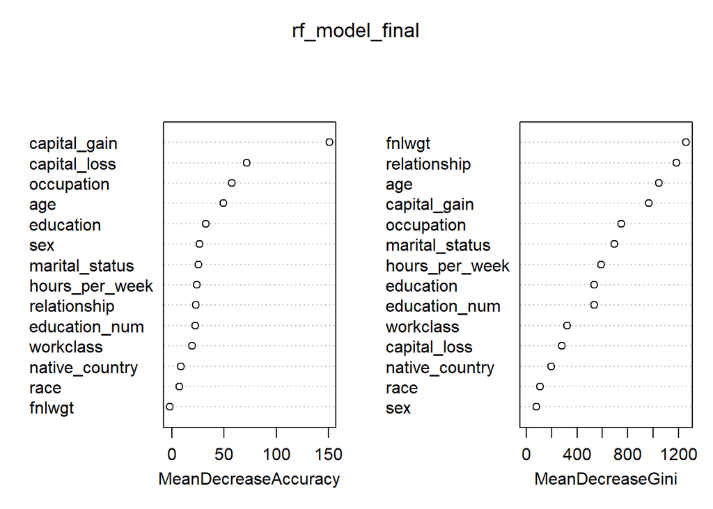

```r
# Plot variable importance
varImpPlot(rf_model_final)
```

## 8 Model Comparison

Here, we compare the performance of all models using accuracy and other metrics.

```r
# Extract accuracy from the confusion matrices
acc_cart <- as.numeric(confusionMatrix(pred_cart, test$income)$overall['Accuracy'])
acc_log <- as.numeric(confusionMatrix(factor(log_class, levels = levels(test$income)), test$income)$overall['Accuracy'])
acc_bag <- as.numeric(confusionMatrix(bag_pred, test$income)$overall['Accuracy'])
acc_rf <- as.numeric(confusionMatrix(rf_pred, test$income)$overall['Accuracy'])

# Print accuracy values to ensure they are valid
print(acc_cart)
```

```
[1] 0.8181667
```

```r
print(acc_log)
```

```
[1] 0.2522791
```

```r
print(acc_bag)
```

```
[1] 0.7633018
```

```r
print(acc_rf)
```

```
[1] 0.7719211
```

From the output, the most accurate model is the cart classification, followed by the random forest model. The least accurate model was the logistical regression model, indicating it was underfitting and not suitable for more complex problems.